# R project by Valentin Lapparov

This is a project for “R for statistics” course.

### Context:

The data were obtained in a survey of students math and portuguese language courses in secondary school. It contains a lot of interesting social, gender and study information about students. You can use it for some EDA or try to predict students final grade.

### Content:

Attributes for both student-mat.csv (Math course) and student-por.csv (Portuguese language course) datasets:

- school - student’s school (binary: ‘GP’ - Gabriel Pereira or ‘MS’ - Mousinho da Silveira)
- sex - student’s sex (binary: ‘F’ - female or ‘M’ - male)
- age - student’s age (numeric: from 15 to 22)
- address - student’s home address type (binary: ‘U’ - urban or ‘R’ - rural)
- famsize - family size (binary: ‘LE3’ - less or equal to 3 or ‘GT3’ - greater than 3)
- Pstatus - parent’s cohabitation status (binary: ‘T’ - living together or ‘A’ - apart)
- Medu - mother’s education (numeric: 0 - none, 1 - primary education (4th grade), 2 – 5th to 9th grade, 3 – secondary education or 4 – higher education)
- Fedu - father’s education (numeric: 0 - none, 1 - primary education (4th grade), 2 – 5th to 9th grade, 3 – secondary education or 4 – higher education)
- Mjob - mother’s job (nominal: ‘teacher’, ‘health’ care related, civil ‘services’ (e.g. administrative or police), ‘at_home’ or ‘other’)
- Fjob - father’s job (nominal: ‘teacher’, ‘health’ care related, civil ‘services’ (e.g. administrative or police), ‘at_home’ or ‘other’)
- reason - reason to choose this school (nominal: close to ‘home’, school ‘reputation’, ‘course’ preference or ‘other’)
- guardian - student’s guardian (nominal: ‘mother’, ‘father’ or ‘other’)
- traveltime - home to school travel time (numeric: 1 - <15 min., 2 - 15 to 30 min., 3 - 30 min. to 1 hour, or 4 - >1 hour)
- studytime - weekly study time (numeric: 1 - <2 hours, 2 - 2 to 5 hours, 3 - 5 to 10 hours, or 4 - >10 hours)
- failures - number of past class failures (numeric: n if 1<=n<3, else 4)
- schoolsup - extra educational support (binary: yes or no)
- famsup - family educational support (binary: yes or no)
- paid - extra paid classes within the course subject (Math or Portuguese) (binary: yes or no)
- activities - extra-curricular activities (binary: yes or no)
- nursery - attended nursery school (binary: yes or no)
- higher - wants to take higher education (binary: yes or no)
- internet - Internet access at home (binary: yes or no)
- romantic - with a romantic relationship (binary: yes or no)
- famrel - quality of family relationships (numeric: from 1 - very bad to 5 - excellent)
- freetime - free time after school (numeric: from 1 - very low to 5 - very high)
- goout - going out with friends (numeric: from 1 - very low to 5 - very high)
- Dalc - workday alcohol consumption (numeric: from 1 - very low to 5 - very high)
- Walc - weekend alcohol consumption (numeric: from 1 - very low to 5 - very high)
- health - current health status (numeric: from 1 - very bad to 5 - very good)
- absences - number of school absences (numeric: from 0 to 93)

These grades are related with the course subject, Math or Portuguese:

- G1 - first period grade (numeric: from 0 to 20)
- G2 - second period grade (numeric: from 0 to 20)
- G3 - final grade (numeric: from 0 to 20, output target)

### Additional note:

There are several (382) students that belong to both datasets . These students can be identified by searching for identical attributes that characterize each student, as shown in the annexed R file.

### Source Information

- P. Cortez and A. Silva. Using Data Mining to Predict Secondary School Student Performance. In A. Brito and J. Teixeira Eds., Proceedings of 5th FUture BUsiness TEChnology Conference (FUBUTEC 2008) pp. 5-12, Porto, Portugal, April, 2008, EUROSIS, ISBN 978-9077381-39-7.
- Fabio Pagnotta, Hossain Mohammad Amran. Email:fabio.pagnotta@studenti.unicam.it, mohammadamra.hossain ‘@’ studenti.unicam.it University Of Camerino

https://archive.ics.uci.edu/ml/datasets/STUDENT+ALCOHOL+CONSUMPTION

# Preliminary studies:

First, let’s import our data, and have a first look on it’s features:

```r
library("readxl")
library("dplyr")
```

```r
library("ggplot2")
library("DT")
```

```r
data <- read.csv("student-mat.csv")
datatable(data)
```

|  | school | sex | age | address | famsize | Pstatus | Medu | Fedu | Mjob | Fjob | reason | guardian | traveltime | studytime | failures | schoolsup | famsup | paid | activities | nursery | higher | internet | romantic | famrel | freetime | goout | Dalc | Walc | health | … |
| --- | --- | --- | --- | --- | --- | --- | --- | --- | --- | --- | --- | --- | --- | --- | --- | --- | --- | --- | --- | --- | --- | --- | --- | --- | --- | --- | --- | --- | --- | --- |
| 1 | GP | F | 18 | U | GT3 | A | 4 | 4 | at_home | teacher | course | mother | 2 | 2 | 0 | yes | no | no | no | yes | yes | no | no | 4 | 3 | 4 | 1 | 1 | 3 | … |
| 2 | GP | F | 17 | U | GT3 | T | 1 | 1 | at_home | other | course | father | 1 | 2 | 0 | no | yes | no | no | no | yes | yes | no | 5 | 3 | 3 | 1 | 1 | 3 | … |
| 3 | GP | F | 15 | U | LE3 | T | 1 | 1 | at_home | other | other | mother | 1 | 2 | 3 | yes | no | yes | no | yes | yes | yes | no | 4 | 3 | 2 | 2 | 3 | 3 | … |
| 4 | GP | F | 15 | U | GT3 | T | 4 | 2 | health | services | home | mother | 1 | 3 | 0 | no | yes | yes | yes | yes | yes | yes | yes | 3 | 2 | 2 | 1 | 1 | 5 | … |
| 5 | GP | F | 16 | U | GT3 | T | 3 | 3 | other | other | home | father | 1 | 2 | 0 | no | yes | yes | no | yes | yes | no | no | 4 | 3 | 2 | 1 | 2 | 5 | … |
| 6 | GP | M | 16 | U | LE3 | T | 4 | 3 | services | other | reputation | mother | 1 | 2 | 0 | no | yes | yes | yes | yes | yes | yes | no | 5 | 4 | 2 | 1 | 2 | 5 | … |
| 7 | GP | M | 16 | U | LE3 | T | 2 | 2 | other | other | home | mother | 1 | 2 | 0 | no | no | no | no | yes | yes | yes | no | 4 | 4 | 4 | 1 | 1 | 3 | … |
| 8 | GP | F | 17 | U | GT3 | A | 4 | 4 | other | teacher | home | mother | 2 | 2 | 0 | yes | yes | no | no | yes | yes | no | no | 4 | 1 | 4 | 1 | 1 | 1 | … |
| 9 | GP | M | 15 | U | LE3 | A | 3 | 2 | services | other | home | mother | 1 | 2 | 0 | no | yes | yes | no | yes | yes | yes | no | 4 | 2 | 2 | 1 | 1 | 1 | … |
| 10 | GP | M | 15 | U | GT3 | T | 3 | 4 | other | other | home | mother | 1 | 2 | 0 | no | yes | yes | yes | yes | yes | yes | no | 5 | 5 | 1 | 1 | 1 | 5 | … |

[output cut: 385 more lines]

```r
# summary(data)
dim(data)
```

```
## [1] 395  33
```

```r
names(data)
```

```
##  [1] "school"     "sex"        "age"        "address"    "famsize"
##  [6] "Pstatus"    "Medu"       "Fedu"       "Mjob"       "Fjob"
## [11] "reason"     "guardian"   "traveltime" "studytime"  "failures"
## [16] "schoolsup"  "famsup"     "paid"       "activities" "nursery"
## [21] "higher"     "internet"   "romantic"   "famrel"     "freetime"
## [26] "goout"      "Dalc"       "Walc"       "health"     "absences"
## [31] "G1"         "G2"         "G3"
```

# Alcohol consumption by age

It is interesting to find out which age group consumes the most alcohol and what is the tendence.

Let us have a look first on the Average Daily and Week-End Alcohol consumption:

```r
average_cons <- data %>%
  select("age", "Dalc") %>%
  group_by(age) %>%
  summarise(average_daily_cons = mean(Dalc))
```

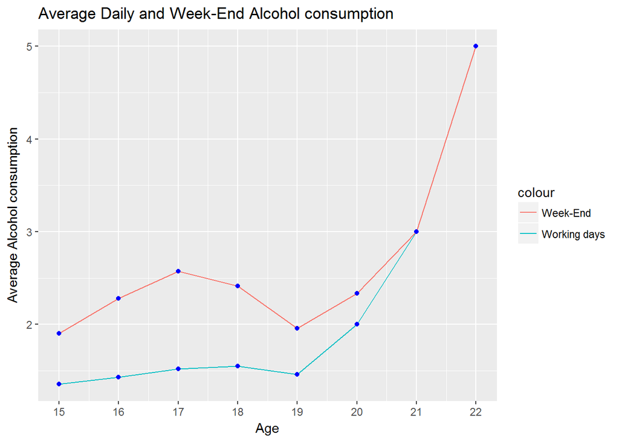

```r
average_cons_we <- data %>%
  select("age", "Walc") %>%
  group_by(age) %>%
  summarise(average_daily_cons = mean(Walc))

  ggplot()+
  geom_line(aes(age, average_daily_cons, color = "Working days"), average_cons)+
  geom_line(aes(age, average_daily_cons, color = "Week-End"), average_cons_we)+
  geom_point(aes(age, average_daily_cons), average_cons, col = "blue")+
  geom_point(aes(age, average_daily_cons), average_cons_we, col = "blue")+
  xlab("Age")+
  ylab("Average Alcohol consumption")+
  ggtitle("Average Daily and Week-End Alcohol consumption")+
    scale_x_continuous(breaks = round(seq(15, 22, by = 1),1))
```

From this plot we can see that basicly the older the individual, the more he consumes alcohol while working week. On the other hand we can see increased consumtion among the young people (17 years-old students). It is interestiong to see the comparaison between daily and weekend average consumption:

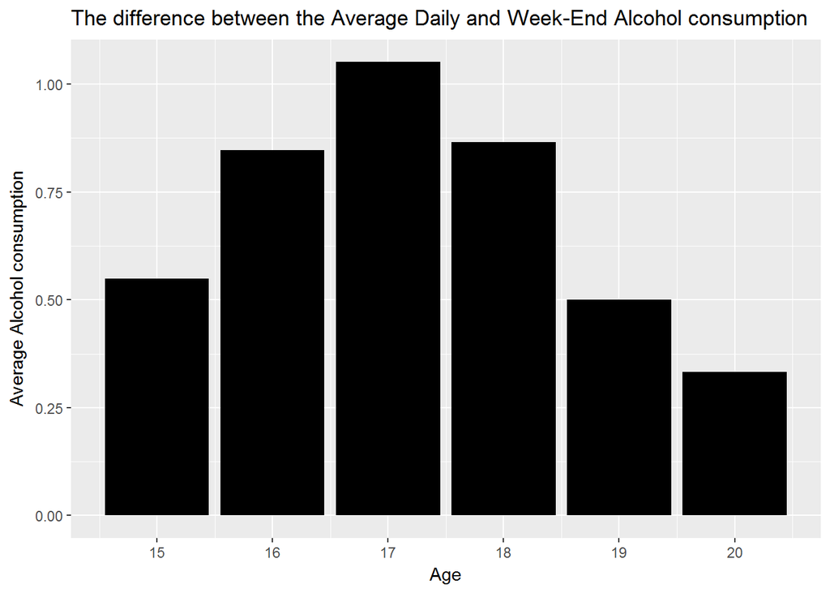

```r
diff_day_we <- average_cons_we %>% inner_join(average_cons, by = "age") %>%
  mutate(d = average_daily_cons.x - average_daily_cons.y) %>%
  select("age", "d")



  diff_day_we[diff_day_we$d != 0,] %>% ggplot(aes(x=age, y=d))+
  geom_col(fill = "black")+
  xlab("Age")+
  ylab("Average Alcohol consumption")+
  ggtitle("The difference between the Average Daily and Week-End Alcohol consumption")+
    scale_x_continuous(breaks = round(seq(15, 20, by = 1),1))
```

This tendence reflects the fact of increased interest to alcohol due to age (I mean that 22-old student is usually more experienced than 17-year old one).

# Academic Results and Alcohol consumption

It is very interesting to look if alcohol consumption affects on the academic results. Let us take the marks for the first and the second period and have a look:

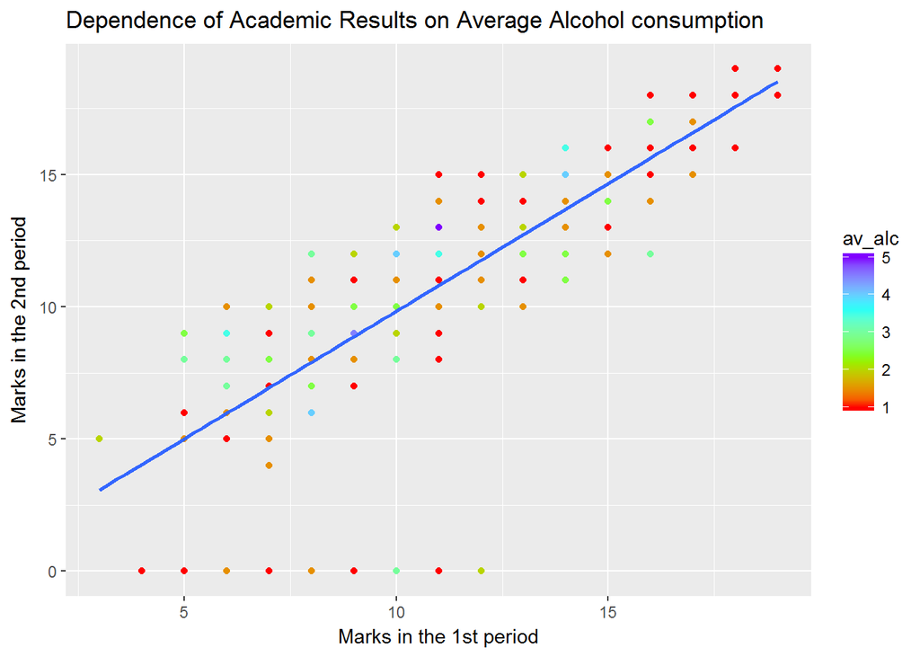

```r
res1 <- data %>%
  select("Dalc", "Walc", "absences", "G1", "G2", "G3") %>%
  mutate(av_alc = (Dalc + Walc)/2) %>%
  select("av_alc", "absences", "G1", "G2", "G3")

res1 %>%
  ggplot(aes(x = G1, y = G2, color = av_alc)) +
  geom_point() +
  xlab("Marks in the 1st period")+
  ylab("Marks in the 2nd period")+
  ggtitle("Dependence of Academic Results on Average Alcohol consumption")+
  geom_smooth(method = "lm", se = FALSE) +
  scale_colour_gradientn(colours=rainbow(4))
```

Let us take a look on the student’s marks with the average alcohol consumption rate more than 2.5:

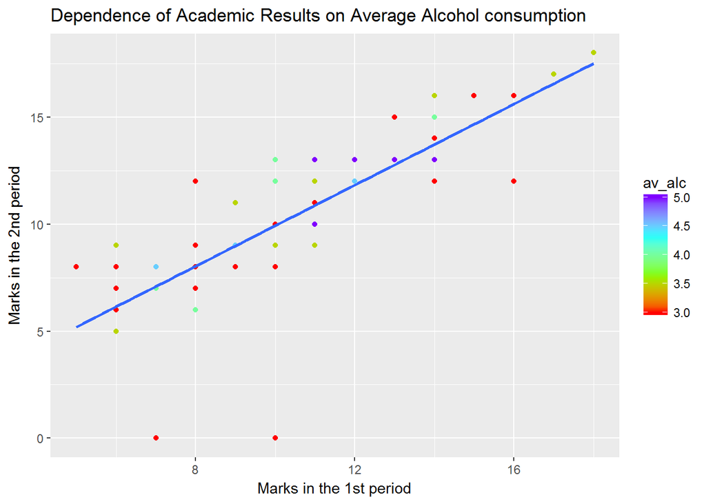

```r
res1[res1$av_alc > 2.5,] %>%
  ggplot(aes(x = G1, y = G2, color = av_alc)) +
  geom_point() +
  xlab("Marks in the 1st period")+
  ylab("Marks in the 2nd period")+
  ggtitle("Dependence of Academic Results on Average Alcohol consumption")+
  geom_smooth(method = "lm", se = FALSE) +
  scale_colour_gradientn(colours=rainbow(4))
```

From this plot we can’t conclude that the alcohol consumption really affects the academic results. But what happenes if we will compare the marks for the 1st and the 3rd period?

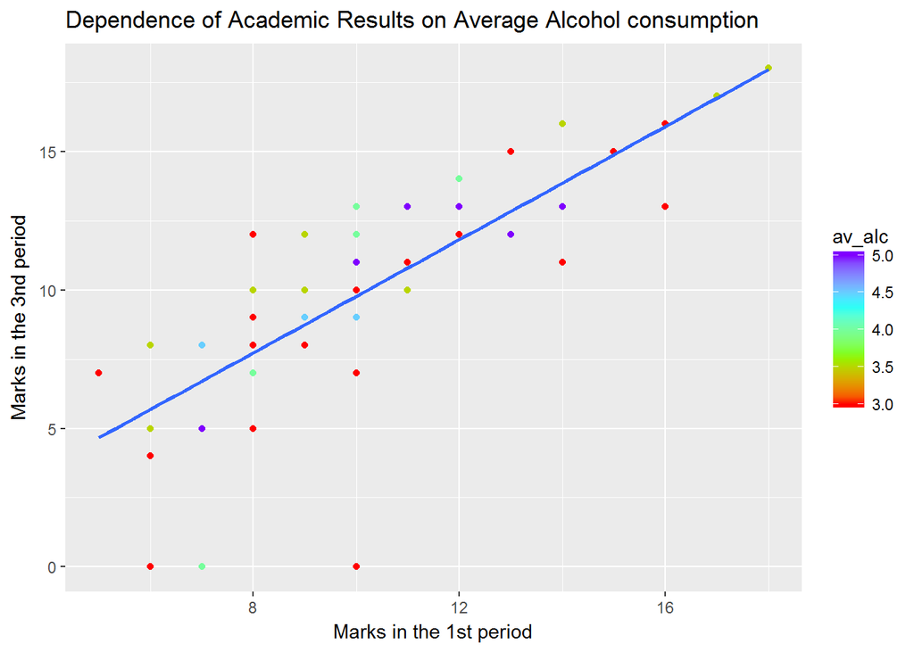

```r
res1[res1$av_alc > 2.5,] %>%
  ggplot(aes(x = G1, y = G3, color = av_alc)) +
  geom_point() +
  xlab("Marks in the 1st period")+
  ylab("Marks in the 3nd period")+
  ggtitle("Dependence of Academic Results on Average Alcohol consumption")+
  geom_smooth(method = "lm", se = FALSE) +
  scale_colour_gradientn(colours=rainbow(4))
```

Once again this is not evident that the alcohol consumption really affects the academic results.

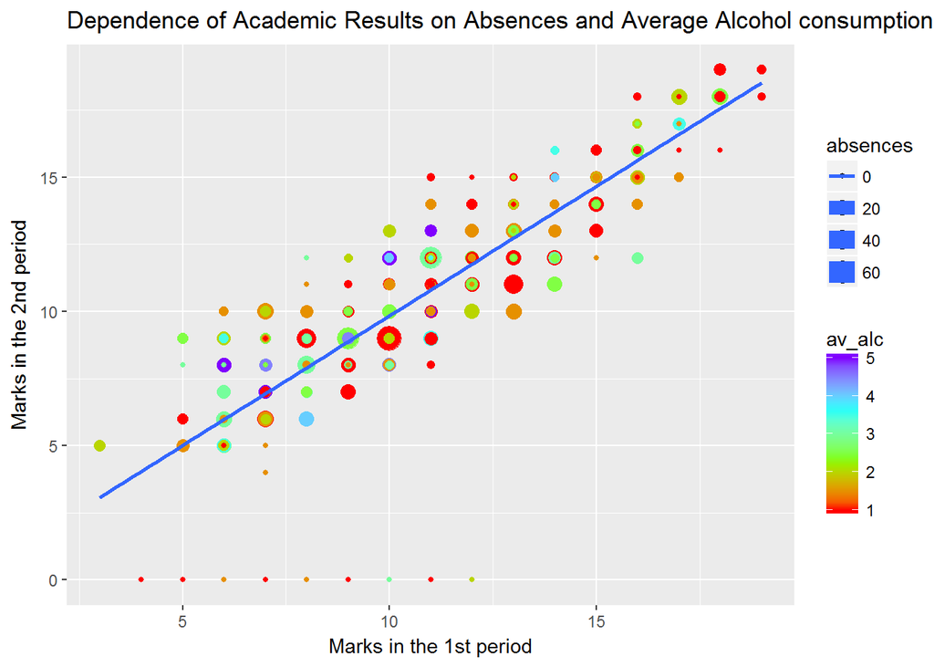

```r
res1 %>%
  ggplot(aes(x = G1, y = G2, size = absences, color = av_alc)) +
  geom_point() +
  xlab("Marks in the 1st period")+
  ylab("Marks in the 2nd period")+
  ggtitle("Dependence of Academic Results on Absences and Average Alcohol consumption")+
  geom_smooth(method = "lm", se = FALSE) +
  scale_colour_gradientn(colours=rainbow(4))
```

Let’s have a look on the correlation matrix to find out the possible relations between our variables.

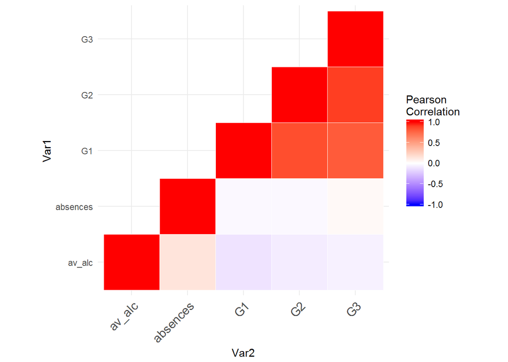

```r
cormat <- round(cor(res1),2)
#head(cormat)

library(reshape2)
melted_cormat <- melt(cormat)
#head(melted_cormat)


# Get lower triangle of the correlation matrix
  get_lower_tri<-function(cormat){
    cormat[upper.tri(cormat)] <- NA
    return(cormat)
  }
  # Get upper triangle of the correlation matrix
  get_upper_tri <- function(cormat){
    cormat[lower.tri(cormat)]<- NA
    return(cormat)
  }

  upper_tri <- get_upper_tri(cormat)
# upper_tri

# Melt the correlation matrix
melted_cormat <- melt(upper_tri, na.rm = TRUE)
# Heatmap

ggplot(data = melted_cormat, aes(Var2, Var1, fill = value))+
 geom_tile(color = "white")+
 scale_fill_gradient2(low = "blue", high = "red", mid = "white",
   midpoint = 0, limit = c(-1,1), space = "Lab",
   name="Pearson\nCorrelation") +
  theme_minimal()+
 theme(axis.text.x = element_text(angle = 45, vjust = 1,
    size = 12, hjust = 1))+
 coord_fixed()
```

As we can see, there is no fort correlation between alcohol consumption and the academic results.

# Towards a real mathematical model

First, let’s convert our data to something, that we can use for model constructing. We will replace all characters by natural numbers in order to construct our model.

```r
df <- data
df$school <- factor(df$school, labels = c(1,2))
df$sex <- factor(df$sex, labels = c(1,2))
df$address <- factor(df$address, labels = c(1,2))
df$famsize <- factor(df$famsize, labels = c(1,2))
df$Pstatus <- factor(df$Pstatus, labels = c(1:2))
df$Mjob <- factor(df$Mjob, labels = c(1:5))
df$Fjob <- factor(df$Fjob, labels = c(1:5))
df$reason <- factor(df$reason, labels = c(1:4))
df$guardian <- factor(df$guardian, labels = c(1:3))
for (i in c(16:23)) {
  df[,i] <- factor(df[,i], labels = c(1,2))
}
```

And also we will explain an average of grades obtained:

```r
df <- df %>% mutate(y = (G1+G2+G3)/3) %>% select(-G1, -G2, -G3)
datatable(df)
```

|  | school | sex | age | address | famsize | Pstatus | Medu | Fedu | Mjob | Fjob | reason | guardian | traveltime | studytime | failures | schoolsup | famsup | paid | activities | nursery | higher | internet | romantic | famrel | freetime | goout | Dalc | Walc | health | … |
| --- | --- | --- | --- | --- | --- | --- | --- | --- | --- | --- | --- | --- | --- | --- | --- | --- | --- | --- | --- | --- | --- | --- | --- | --- | --- | --- | --- | --- | --- | --- |
| 1 | 1 | 1 | 18 | 2 | 1 | 1 | 4 | 4 | 1 | 5 | 1 | 2 | 2 | 2 | 0 | 2 | 1 | 1 | 1 | 2 | 2 | 1 | 1 | 4 | 3 | 4 | 1 | 1 | 3 | … |
| 2 | 1 | 1 | 17 | 2 | 1 | 2 | 1 | 1 | 1 | 3 | 1 | 1 | 1 | 2 | 0 | 1 | 2 | 1 | 1 | 1 | 2 | 2 | 1 | 5 | 3 | 3 | 1 | 1 | 3 | … |
| 3 | 1 | 1 | 15 | 2 | 2 | 2 | 1 | 1 | 1 | 3 | 3 | 2 | 1 | 2 | 3 | 2 | 1 | 2 | 1 | 2 | 2 | 2 | 1 | 4 | 3 | 2 | 2 | 3 | 3 | … |
| 4 | 1 | 1 | 15 | 2 | 1 | 2 | 4 | 2 | 2 | 4 | 2 | 2 | 1 | 3 | 0 | 1 | 2 | 2 | 2 | 2 | 2 | 2 | 2 | 3 | 2 | 2 | 1 | 1 | 5 | … |
| 5 | 1 | 1 | 16 | 2 | 1 | 2 | 3 | 3 | 3 | 3 | 2 | 1 | 1 | 2 | 0 | 1 | 2 | 2 | 1 | 2 | 2 | 1 | 1 | 4 | 3 | 2 | 1 | 2 | 5 | … |
| 6 | 1 | 2 | 16 | 2 | 2 | 2 | 4 | 3 | 4 | 3 | 4 | 2 | 1 | 2 | 0 | 1 | 2 | 2 | 2 | 2 | 2 | 2 | 1 | 5 | 4 | 2 | 1 | 2 | 5 | … |
| 7 | 1 | 2 | 16 | 2 | 2 | 2 | 2 | 2 | 3 | 3 | 2 | 2 | 1 | 2 | 0 | 1 | 1 | 1 | 1 | 2 | 2 | 2 | 1 | 4 | 4 | 4 | 1 | 1 | 3 | … |
| 8 | 1 | 1 | 17 | 2 | 1 | 1 | 4 | 4 | 3 | 5 | 2 | 2 | 2 | 2 | 0 | 2 | 2 | 1 | 1 | 2 | 2 | 1 | 1 | 4 | 1 | 4 | 1 | 1 | 1 | … |
| 9 | 1 | 2 | 15 | 2 | 2 | 1 | 3 | 2 | 4 | 3 | 2 | 2 | 1 | 2 | 0 | 1 | 2 | 2 | 1 | 2 | 2 | 2 | 1 | 4 | 2 | 2 | 1 | 1 | 1 | … |
| 10 | 1 | 2 | 15 | 2 | 1 | 2 | 3 | 4 | 3 | 3 | 2 | 2 | 1 | 2 | 0 | 1 | 2 | 2 | 2 | 2 | 2 | 2 | 1 | 5 | 5 | 1 | 1 | 1 | 5 | … |

[output cut: 385 more lines]

```r
sapply(df, typeof)
```

```
##     school        sex        age    address    famsize    Pstatus
##  "integer"  "integer"  "integer"  "integer"  "integer"  "integer"
##       Medu       Fedu       Mjob       Fjob     reason   guardian
##  "integer"  "integer"  "integer"  "integer"  "integer"  "integer"
## traveltime  studytime   failures  schoolsup     famsup       paid
##  "integer"  "integer"  "integer"  "integer"  "integer"  "integer"
## activities    nursery     higher   internet   romantic     famrel
##  "integer"  "integer"  "integer"  "integer"  "integer"  "integer"
##   freetime      goout       Dalc       Walc     health   absences
##  "integer"  "integer"  "integer"  "integer"  "integer"  "integer"
##          y
##   "double"
```

By the following steps we are looking for the number of variables needed to “explain”" the grades.

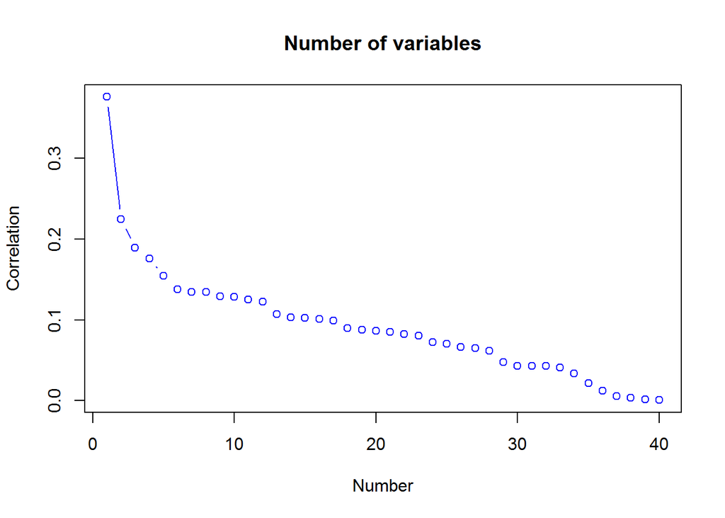

```r
train <- data.frame(model.matrix( ~ .- 1, data=df))
cor_temp <- cor(train, train, method = "pearson")
cor_final <- data.frame(cor = cor_temp[1:40,41], varn = names(cor_temp[1:40,41]))
cor_final <- cor_final %>%
  mutate(cor_abs = abs(cor)) %>%
  arrange(desc(cor_abs))
plot(cor_final$cor_abs, type="b", col = "blue",xlab = "Number", ylab = "Correlation", main = "Number of variables")
```

```r
train_final <- cor_final %>%
  filter(cor_abs > 0.1)

train_final <- train %>%
  select("y", train_final$varn)

head(train_final)
```

| y | famsize2 | guardian3 | reason4 | Mjob2 | Fjob4 | goout | age | Walc | traveltime | health | studytime | Fjob2 | sex2 | romantic2 | guardian2 | Dalc |
| --- | --- | --- | --- | --- | --- | --- | --- | --- | --- | --- | --- | --- | --- | --- | --- | --- |
| 5.666667 | 0 | 0 | 0 | 0 | 0 | 4 | 18 | 1 | 2 | 3 | 2 | 0 | 0 | 0 | 1 | 1 |
| 5.333333 | 0 | 0 | 0 | 0 | 0 | 3 | 17 | 1 | 1 | 3 | 2 | 0 | 0 | 0 | 0 | 1 |
| 8.333333 | 1 | 0 | 0 | 0 | 0 | 2 | 15 | 3 | 1 | 3 | 2 | 0 | 0 | 0 | 1 | 2 |
| 14.666667 | 0 | 0 | 0 | 1 | 1 | 2 | 15 | 1 | 1 | 5 | 3 | 0 | 0 | 1 | 1 | 1 |
| 8.666667 | 0 | 0 | 0 | 0 | 0 | 2 | 16 | 2 | 1 | 5 | 2 | 0 | 0 | 0 | 0 | 1 |
| 15.000000 | 1 | 0 | 1 | 0 | 0 | 2 | 16 | 2 | 1 | 5 | 2 | 0 | 1 | 0 | 1 | 1 |

Let us now build a new correlation matrix taking into account our train data and have a look at our model summary.

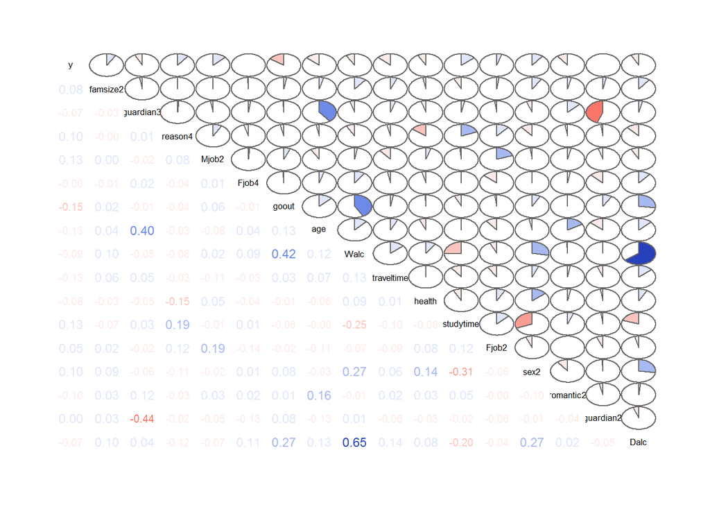

```r
library("corrgram")
corrgram(train_final,lower.panel=panel.cor,upper.panel=panel.pie, cor.method = "pearson")
```

```r
summary(lm(data = train_final, y ~ .))
```

```
##
## Call:
## lm(formula = y ~ ., data = train_final)
##
## Residuals:
##     Min      1Q  Median      3Q     Max
## -8.7561 -2.3395  0.0118  2.5159  9.3478
##
## Coefficients:
##              Estimate Std. Error t value Pr(>|t|)
## (Intercept) 15.451534   2.716353   5.688 2.57e-08 ***
## famsize2     0.753290   0.396116   1.902  0.05797 .
## guardian3   -0.356020   0.791813  -0.450  0.65324
## reason4      0.414121   0.417421   0.992  0.32179
## Mjob2        1.710860   0.657569   2.602  0.00964 **
## Fjob4       -0.045976   0.406897  -0.113  0.91010
## goout       -0.490397   0.178093  -2.754  0.00618 **
## age         -0.225060   0.156897  -1.434  0.15227
## Walc        -0.029620   0.198493  -0.149  0.88145
## traveltime  -0.525348   0.260846  -2.014  0.04472 *
## health      -0.244972   0.131783  -1.859  0.06382 .
## studytime    0.715756   0.230915   3.100  0.00208 **
## Fjob2       -0.184105   0.897302  -0.205  0.83754
## sex2         1.270039   0.390062   3.256  0.00123 **
## romantic2   -0.613657   0.384649  -1.595  0.11147
## guardian2   -0.085477   0.438322  -0.195  0.84549
## Dalc        -0.006229   0.268533  -0.023  0.98151
## ---
## Signif. codes:  0 '***' 0.001 '**' 0.01 '*' 0.05 '.' 0.1 ' ' 1
##
## Residual standard error: 3.516 on 378 degrees of freedom
## Multiple R-squared:  0.1324, Adjusted R-squared:  0.09567
## F-statistic: 3.605 on 16 and 378 DF,  p-value: 4.043e-06
```

We see that R-square is not very high (0.13), but this is not as bad as estimated: we build a model, based on the data, where we manually changed data.

# PCA

Now we will use a principal component analysis (PCA). It is a statistical procedure that uses an orthogonal transformation to convert a set of observations of possibly correlated variables into a set of values of linearly uncorrelated variables called principal components (or sometimes, principal modes of variation).

As we know, the number of principal components is less than or equal to the smaller of the number of original variables or the number of observations. This transformation is defined in such a way that the first principal component has the largest possible variance (that is, accounts for as much of the variability in the data as possible), and each succeeding component in turn has the highest variance possible under the constraint that it is orthogonal to the preceding components. The resulting vectors are an uncorrelated orthogonal basis set.

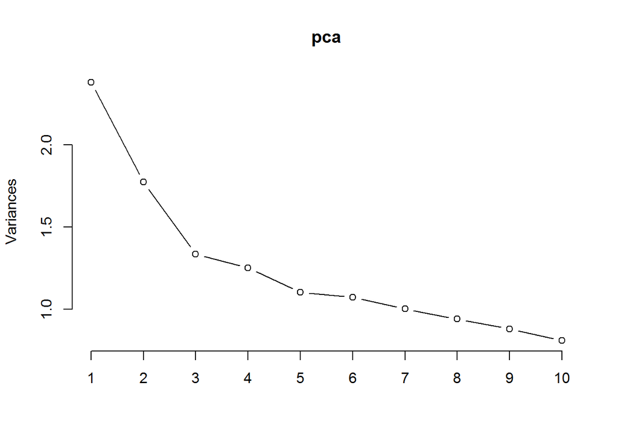

```r
data_pca <- train_final %>% select(-y)
pca <- prcomp(data_pca, scale. = TRUE, center = TRUE)
plot(pca, type="l")
```

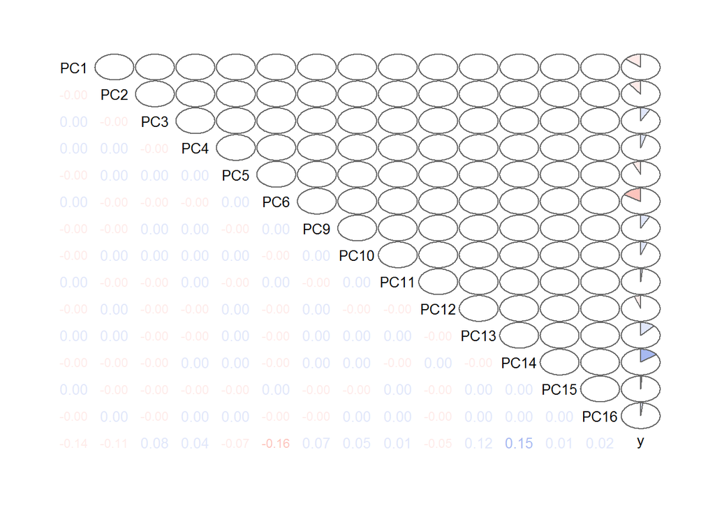

```r
pca_df <- data.frame(pca$x)
pca_df <- pca_df %>% select(-PC7,-PC8)
pca_df$y = train_final$y

corrgram(pca_df,lower.panel=panel.cor,upper.panel=panel.pie)
```

```r
model <- lm(data = pca_df, y ~ .)
summary(model)
```

```
##
## Call:
## lm(formula = y ~ ., data = pca_df)
##
## Residuals:
##     Min      1Q  Median      3Q     Max
## -8.3235 -2.3480 -0.1107  2.4665  9.0292
##
## Coefficients:
##             Estimate Std. Error t value Pr(>|t|)
## (Intercept) 10.67932    0.17787  60.041  < 2e-16 ***
## PC1         -0.33814    0.11549  -2.928 0.003619 **
## PC2         -0.29247    0.13372  -2.187 0.029345 *
## PC3          0.25134    0.15405   1.632 0.103587
## PC4          0.14222    0.15923   0.893 0.372318
## PC5         -0.23301    0.16954  -1.374 0.170136
## PC6         -0.58170    0.17180  -3.386 0.000783 ***
## PC9          0.29352    0.18970   1.547 0.122613
## PC10         0.21829    0.19779   1.104 0.270437
## PC11         0.05116    0.20475   0.250 0.802838
## PC12        -0.24732    0.21773  -1.136 0.256713
## PC13         0.54982    0.22212   2.475 0.013746 *
## PC14         0.70001    0.22716   3.082 0.002209 **
## PC15         0.04598    0.26505   0.173 0.862374
## PC16         0.10006    0.31912   0.314 0.754030
## ---
## Signif. codes:  0 '***' 0.001 '**' 0.01 '*' 0.05 '.' 0.1 ' ' 1
##
## Residual standard error: 3.535 on 380 degrees of freedom
## Multiple R-squared:  0.1181, Adjusted R-squared:  0.0856
## F-statistic: 3.635 on 14 and 380 DF,  p-value: 1.087e-05
```

(credits for the biplot function crayola http://stackoverflow.com/questions/6578355/plotting-pca-biplot-with-ggplot2)

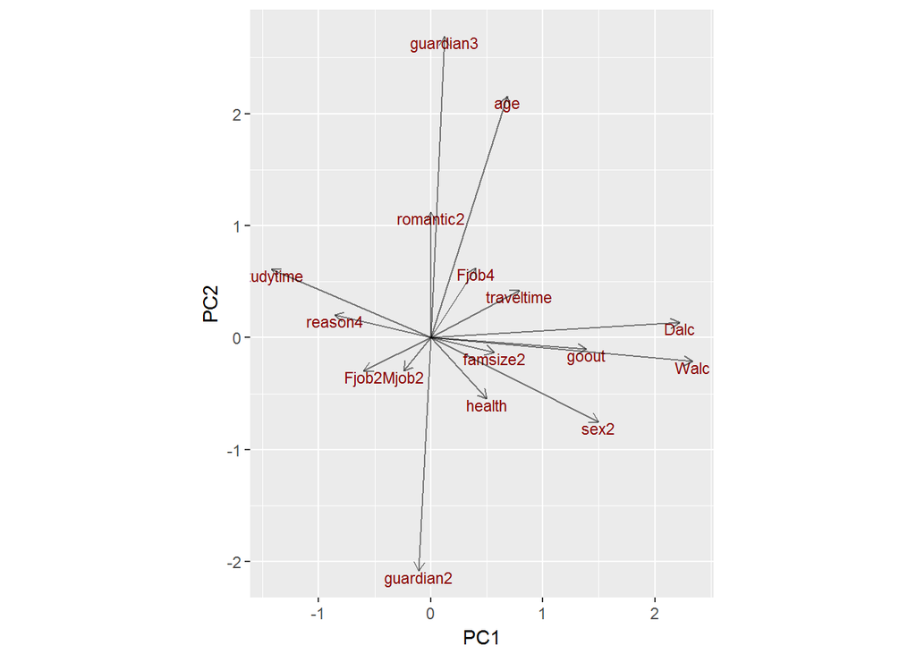

```r
PCbiplot <- function(PC, x="PC1", y="PC2") {
    data <- data.frame( PC$x)
    plot <- ggplot(data, aes_string(x=x, y=y))
    datapc <- data.frame(varnames=row.names(PC$rotation), PC$rotation)
    mult <- min(
        (max(data[,y]) - min(data[,y])/(max(datapc[,y])-min(datapc[,y]))),
        (max(data[,x]) - min(data[,x])/(max(datapc[,x])-min(datapc[,x])))
        )
    datapc <- transform(datapc,
            v1 = .7 * mult * (get(x)),
            v2 = .7 * mult * (get(y))
            )
    plot <- plot + coord_equal() + geom_text(data=datapc, aes(x=v1, y=v2, label=varnames), size = 3, vjust=1, color="darkred")
    plot <- plot + geom_segment(data=datapc, aes(x=0, y=0, xend=v1, yend=v2), arrow=arrow(length=unit(0.2,"cm")), alpha=0.5, color="black")
    plot
}

PCbiplot(pca)
```